# Análisis developers github

Vamos a analizar los developers registrados en github más populares para los lenguajes R y Python con el objetivo de estar informados de quiénes son los máximos influyentes en ambos lenguajes.

*Autenticarse en github para lanzar el script ya que hay limitaciones en el uso de la API:*

- https://developer.github.com/v3/#rate-limiting
- *For requests using Basic Authentication or OAuth, you can make up to 5,000 requests per hour.*
- *For unauthenticated requests, the rate limit allows you to make up to 60 requests per hour.*

#### Indicar credenciales de usuario de github para poder ejecutar correctamente todo el script

```r
user_github = 'david-carrasco'
pass_github = 'davecray5250'
```

Opciones para la conexión con la API a través de RCurl

```r
curl.opts = list(userpwd = paste(user_github, pass_github, sep=':'), ssl.verifypeer = FALSE,
                 useragent = 'curl', httpauth = 1L)
```

## Carga Librerías

```r
library(RCurl)
library(rjson)
library(plyr)
library(ggplot2)
library(plotly)
```

## Constantes

```r
followers <- 300
repos <- 1
```

## Definición de funciones

**pagination**

- Devuelve el resultado de la query de url_paginar ya que la API muestra un máximo de 100 resultados por página

```r
pagination <- function(url_paginar, num_page){
  nueva_pagina <- gsub('&page=(\\d+)', paste('&page=', as.character(num_page), sep=''), url_paginar)
  results_page <- fromJSON(getURL(nueva_pagina, .opts = curl.opts))
  return(results_page)
}
```

**top_developers_by_language**

- Args:
  - programming_language: Lenguaje de programación por el que buscar
  - min_followers: Condición para la query como mínimo de followers
  - min_repos : Condición para la query como mínimo de repositorios
- Return:
  - Devuelve lista ordenada por numero de followers con los top developers por el programming_language
- API:
  - https://developer.github.com/v3/search/#search-code

```r
top_developers_by_language <- function(programming_language, min_followers, min_repos){
  type_user <- 'User'
  page <- 1
  results_per_page <- 100
  url <- sprintf('https://api.github.com/search/users?q=language:%s+repos:>%i+followers:>%i+sort:followers+type:%s&per_page=%i&page=%i', programming_language, min_repos, min_followers, type_user, results_per_page, page)

  top_developers <- fromJSON(getURL(url, .opts = curl.opts))

  #Número total de páginas para obtener todos los developers
  total_pages <- ceiling(top_developers$total_count / results_per_page)

  if (total_pages > 1){
    # Append de los nuevos items en list$items
    top_developers$items <- c(top_developers$items,
                              do.call('c', lapply(c(2:total_pages), function(i){pagination(url, i)$items})))
  }

  return(top_developers$items)
}
```

**followers_by_developer**

```r
followers_by_developer <- function(username_developer){

  page <- 1
  results_per_page <- 100
  number_followers <- 0
  url <- sprintf('https://api.github.com/users/%s/followers?per_page=%i&page=%i',
                 username_developer, results_per_page, page)

  repeat{
    result_query <- pagination(url,page)

    if(length(result_query) == 0){
      break
    } else {
      page <- page + 1
      number_followers <- number_followers + length(result_query)
    }
  }

  return(number_followers)
}
```

**repositories_by_developer**

- Args:
  - developer: username del developer
  - programming_language: Lenguaje de programación del developer por el que buscamos
- Return:
  - Devuelve lista con el username del developer y el nombre, descripción, url y stars de cada uno de los repositorios del propio developer filtrados por el programming_language indicado
- API:
  - https://developer.github.com/v3/repos/#list-user-repositories

```r
repositories_by_developer <- function(username, programming_language){
  url <- sprintf('https://api.github.com/users/%s/repos', username)

  repos <- fromJSON(getURL(url, .opts = curl.opts))


  repos <- sapply(repos, function(element){
                            if (!is.null(element$language) && element$language == programming_language){
                              return(list(username, programming_language, element$name,
                                          element$description, element$html_url, element$stargazers_count))
                            }})

  return(repos[lapply(repos,length)>0])
}
```

## Preparación de datos

Creamos un dataset para cada lenguaje añadiendo una columna para identificar el lenguaje con el developer

Dataframe top developers de Python

```r
top_developers_Python <- top_developers_by_language('python', followers, repos)
df_top_developers_Python <- as.data.frame(do.call('rbind', top_developers_Python))
df_top_developers_Python <- as.data.frame(sapply(df_top_developers_Python, as.character),
                                          stringsAsFactors = FALSE)
df_top_developers_Python$language <- 'Python'
```

Dataframe top developers de R

```r
top_developers_R <- top_developers_by_language('R', followers, repos)
df_top_developers_R <- as.data.frame(do.call('rbind', top_developers_R))
df_top_developers_R<- as.data.frame(sapply(df_top_developers_R, as.character),
                                           stringsAsFactors = FALSE)
df_top_developers_R$language <- 'R'
```

Join ambos dataframes por el username

```r
df_devs <- join(df_top_developers_Python, df_top_developers_R, by='login', type = 'full')
```

Eliminar filas que no interesan, renombramos columnas y cambiamos el orden de las mismas

```r
df_devs <- df_devs[, c('login', 'html_url', 'followers_url','repos_url', 'language')]
names(df_devs) <- c('user_name', 'user_page', 'followers_url', 'repos_url', 'language')
df_devs <- df_devs[, c('language', 'user_name', 'user_page', 'followers_url', 'repos_url')]
```

Búsqueda del número de followers de cada developer y se añade en una nueva columna

**Este paso tarda varios minutos**

```r
df_devs$num_followers <- sapply(df_devs$user_name, followers_by_developer)
```

Ordenamos el dataframe por num_followers

```r
df_devs <- df_devs[order(df_devs$num_followers, decreasing = TRUE), ]
```

Obtenemos la lista de repositorios de cada developer y creamos un dataframe con los repos más populares de los developers del dataframe df_devs creado anteriormente

```r
repositories <- mapply(repositories_by_developer, df_devs$user_name, df_devs$language)
repositories <- unlist(repositories, recursive = FALSE)
repositories <- as.data.frame(do.call('rbind', repositories))

#Renombramos filas y columnas
rownames(repositories) <- 1:nrow(repositories)
names(repositories) <- c('user_name', 'language', 'name_repo', 'description_repo',
                         'url_repo', 'stars_repo')

#Cambiamos tipo de las columnas a character excepto la última (stars_repo) que es tipo integer
repositories <- as.data.frame(sapply(repositories, as.character), stringsAsFactors = FALSE)
repositories$stars_repo <- as.integer(repositories$stars_repo)
```

Ordenamos el dataframe por stars_repo

```r
repositories <- repositories[order(repositories$stars_repo, decreasing = TRUE), ]
```

## Insights

### Top 10 developers agrupados por lenguaje de programación

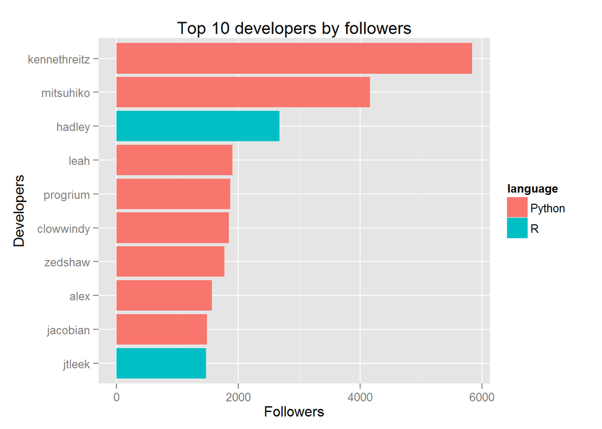

[figure not shown]

```r
developers_top_10 <- df_devs[1:10,]
ggplot(data=developers_top_10, aes(x=reorder(user_name, num_followers), y=num_followers, fill=language)) +
       geom_bar(stat="identity") + xlab("Developers") + ylab("Followers") +
       ggtitle("Top 10 developers by followers") + coord_flip()
```

### Top 10 repositorios agrupados por developer

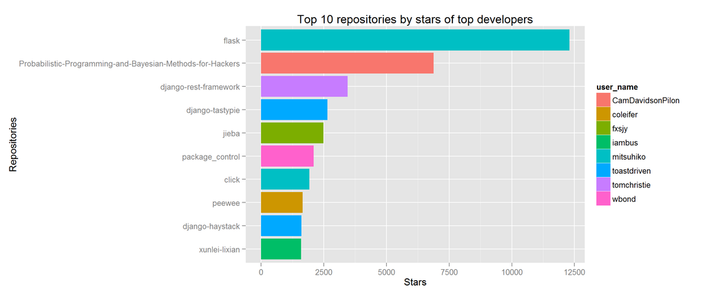

[figure not shown]

```r
repositories_top_10 <- repositories[1:10,]
ggplot(data=repositories_top_10, aes(x=reorder(name_repo, stars_repo), y=stars_repo, fill=user_name)) +
       geom_bar(stat="identity") + xlab("Repositories") + ylab("Stars") +
       ggtitle("Top 10 repositories by stars of top developers") +
       theme(text = element_text(size=12)) + coord_flip()
```

TODO:

Add url links to the charts to jump directly to the developer/repository webpage

### Bibliografía:

- https://developer.github.com/v3/search/#search-users
- https://stackoverflow.com/questions/15415485/concatenate-list-of-lists-in-r
- https://stackoverflow.com/questions/12344982/r-lapply-statement-with-index
- https://stackoverflow.com/questions/13169305/httr-github-api-callback-url-issues
- https://stackoverflow.com/questions/12302941/convert-curl-code-into-r-via-the-rcurl-package
- https://stackoverflow.com/questions/16121463/using-rcurl-httr-for-github-basic-authorization
- http://www.r-bloggers.com/ggplot2-cheatsheet-for-barplots/
- http://www.cookbook-r.com/Graphs/Bar_and_line_graphs_(ggplot2)/
- https://stackoverflow.com/questions/6455088/how-to-put-labels-over-geom-bar-in-r-with-ggplot2
- https://stackoverflow.com/questions/10941225/horizontal-barplot-in-ggplot2
- http://www.cookbook-r.com/Graphs/Facets_(ggplot2)/#facet_grid